# supplement 2

Steve Simon

April 8, 2018

This file creates various formulas and graphs needed to illustrate the underlying theory behind the data analyses in survival-lecture-2.Rmd. I am sharing this for those who are curious, but you are not responsible for learning or using the code shown in this supplement.

```r
library(broom)
library(dplyr)
```

```r
library(ggplot2)
library(magrittr)
library(survival)
library(tidyr)
```

## Motivating example

This is a simple distribution of survival probabilities. It is unrepresentative, but easy to work with.

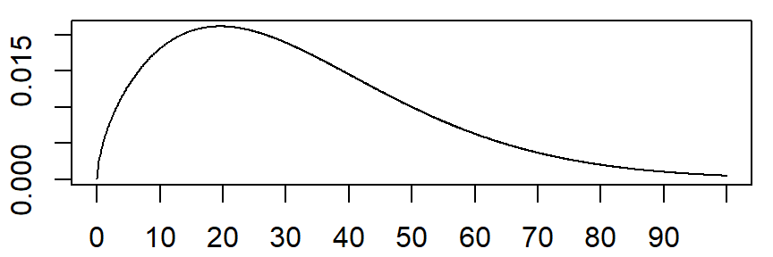

```r
par(mar=c(2.1, 2.1, 0.6, 0.6))
x <- seq(0.001, 100, length=1000)
shp <- 1.6
sc <- 36
y <- dweibull(x, shp, sc)
plot(x, y, type="l", axes=FALSE)
axis(side=1, at=10*(0:10))
axis(side=2)
box()
```

```r
par(mar=c(2.1, 2.1, 0.6, 0.6))
plot(x, y, type="n", axes=FALSE)
axis(side=1, at=10*(0:10))
axis(side=2)
box()
irange <- which((x >= 20) & (x <= 30))
ipolygon <- c(min(irange), irange, max(irange))
polygon(
  x[ipolygon],
  c(0, y[irange], 0),
  density=-1,
  border=NA,
  col="gray")
lines(x, y)
pweibull(30, shp, sc) - pweibull(20, shp, sc); pweibull(60, shp, sc) - pweibull(40, shp, sc)
```

```
## [1] 0.2029587
```

```
## [1] 0.2022789
```

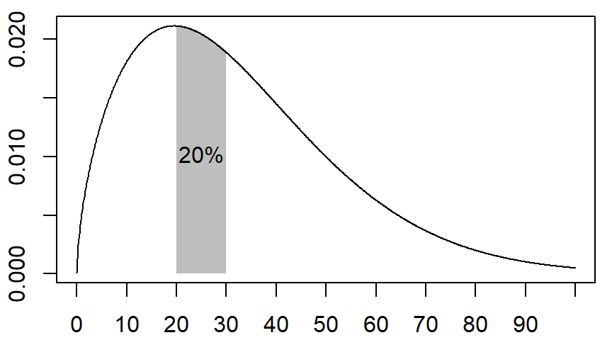

```r
text(25, 0.5*median(y[irange]), "20%")
```

```r
par(mar=c(2.1, 2.1, 0.6, 0.6))
plot(x, y, type="n", axes=FALSE)
axis(side=1, at=10*(0:10))
axis(side=2)
box()
irange <- which((x >= 40) & (x <= 60))
ipolygon <- c(min(irange), irange, max(irange))
polygon(
  x[ipolygon],
  c(0, y[irange], 0),
  density=-1,
  border=NA,
  col="gray")
lines(x, y)
pweibull(30, shp, sc) - pweibull(20, shp, sc)
```

```
## [1] 0.2029587
```

```r
pweibull(60, shp, sc) - pweibull(40, shp, sc)
```

```
## [1] 0.2022789
```

```r
1-pweibull(20, shp, sc)
```

```
## [1] 0.6767531
```

```r
1-pweibull(40, shp, sc)
```

```
## [1] 0.3061687
```

```r
dweibull(20, shp, sc)/(1-pweibull(20, shp, sc))
```

```
## [1] 0.0312359
```

```r
dweibull(40, shp, sc)/(1-pweibull(40, shp, sc))
```

```
## [1] 0.04734477
```

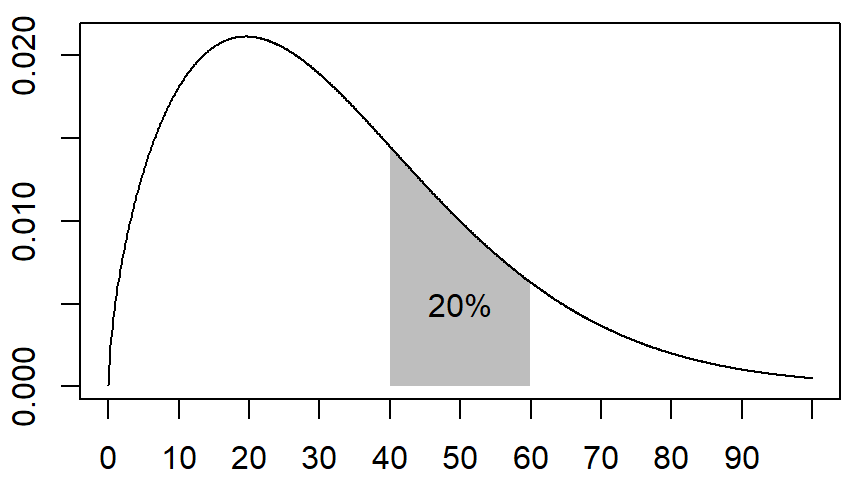

```r
text(50, 0.5*median(y[irange]), "20%")
```

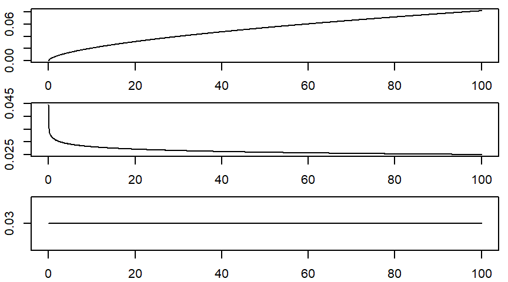

```r
par(mar=c(2.1, 2.1, 0.6, 0.6), mfrow=c(3,1))
h1 <- dweibull(x, shp, sc)/(1-pweibull(x, shp, sc))
plot(x, h1, type="l")
h2 <- dweibull(x, 0.95, sc)/(1-pweibull(x, 0.95, sc))
plot(x, h2, type="l")
h3 <- dweibull(x, 1, sc)/(1-pweibull(x, 1, sc))
plot(x, h3, type="l",axes=FALSE)
axis(side=1)
axis(side=2, at=median(h3), label=round(median(h3), 2))
box()
```

## Formulas

The cumulative hazard function is defined as

$H(t)=\int_0^t h(u)du$

and with a bit of calculus (change of variable), you can show that

$S(t)=e^{-H(t)}$

You can compute the cumulative hazard function as

$\hat{H}(t_j)=\sum_{i=1}^j\frac{d_i}{n_i}$

Let’s suppose that an event or censored value at time $t_i$ has a covariate $X_i$ associated with it that may help in prediction. You no longer has a single density, but a family of densities

$f(t_i, X_i, \beta)$

where $\beta$ is an unknown constant that measures the influence of the covariate. A value of $\beta=0$ implies no influence, a value of $\beta>0$ implies an increase in hazard and $\beta<0$ implies a decrease in hazard.

The likelihood function, given times $t_i$, covariates $X_i$ and indicators $c_i$ equal to zero for censored observation and one for deaths, is

$l(\beta) = \prod_i f(t_i, X_i, \beta)^{c_i} S(t_i, X_i, \beta)^{1-c_i}$

Notice that the likelihood for a censored observation is an average density because

$S(t, X, \beta)=\int_t^\infty f(u, X, \beta)du$

Let’s assume that the density function has an associated hazard function of the form

$h(t_i, X_i, \beta)=e^{X_i \beta}h_0(t_i)$

This is called the proportional hazards assumption.

If you compare the ratio of the hazard function with covariates $X_i$ and $X_j$, you get

$\frac{h(t, X_i, \beta)}{h(t, X_j, \beta)}=e^{(X_i-X_j) \beta}$

which is called the hazard ratio. Notice that the hazard function cancels out, greatly simplifying things.

You cannot use maximum likelihood principles to get an estimate for $\beta$. You can, however, treat the baseline hazard ratio, $h_0(t_i)$ as a nuisance parameter, and maximize the partial likelihood of $\beta$. This maximization simplifies to

$l_p(\beta)=\prod_i \frac{e^{X_i \beta}}{\sum_j e^{X_j \beta}}$

where the summation in the denominator is across all patients still at risk at time $t_i$.

## Three roughly equivalent tests

Define the information matrix,

$I(\beta) = \frac{\partial^2 L_p(\beta)}{\partial^2 \beta}$,

where $L_p$ is the log partial likelihood ($L_p=log(l_p)$).

Then the standard error of $\hat\beta$ is

$se(\hat\beta)=\sqrt{I^{-1}(\hat\beta)}$

This leads to three statistical tests.

Wald test: $\frac{\hat\beta}{se(\hat\beta)}$

Score test: $\frac{\partial L_p/\partial \beta}{\sqrt{I(\beta)}}|_{\beta=0}$

LR test: $G=2(L_p(\beta)-L_p(0))$

The Wald test is the easiest test to compute, but may not be as accurate as the others, especially for small sample sizes.

Save everything for possible re-use.

```r
save.image("../../data/supplement2.RData")
```